# DeMixSC for bulk transcriptomics cell-type deconvolution

## Overview

DeMixSC is a single-cell based deconvolution framework. It provides improved cell-type ratio estimates in complex bulk tissue samples by utilizing a small single-cell benchmark dataset.

This tutorial guides users step-by-step through each deconvolution option provided by DeMixSC:

- **option = “retina”**: Deconvolve bulk retina samples using the prebuilt retina benchmark dataset. In this tutorial, we demonstrate the process using bulk retina samples from the [Ratnapriya et al. AMD retina cohort](https://www.nature.com/articles/s41588-019-0351-9).
- **option = “hgsc”**: Deconvolve bulk high-grade serous ovarian carcinoma (HGSC) samples using the pre benchmark dataset from [Hippen et al. 2023](https://genomebiology.biomedcentral.com/articles/10.1186/s13059-023-03077-7) study. We use HGSC samples from the Lee et al. HGSC cohort as an example.
- **option = “user.defined”**: For this option, users can either (a) provide their own benchmark dataset for running DeMixSC benchmark mode, or (b) provide both a target bulk sample and a benchmark dataset to deconvolve the target data. In this tutorial, AMD retina deconvolution serves as an example to illustrate how to apply this general setting.

Each example section is organized as follows: (1) **Read data**: Load the required data based on the selected option. (2) **Run deconvolution**: Perform deconvolution analysis using DeMixSC. (3) **Visualize results**: Generate visualizations to interpret the deconvolution outputs.

By following this tutorial, users will gain a comprehensive understanding of DeMixSC’s functionalities and be equipped to perform deconvolution across different datasets and conditions.

## Preparation

To run DeMixSC, please make sure your R version is $\geq$ 4.2.1 and install the following R packages with the required version:

- nnls $\geq$ 1.4
- preprocessCore $\geq$ 1.52.1
- doParallel $\geq$ 1.0.17
- pbapply $\geq$ 1.7-2
- sva $\geq$ 3.38.0

```r
# Check and install required packages
# You may receive additional messages if it is the first time for you to install the packages.

# Install BiocManager if necessary
  if (!require("BiocManager", quietly = TRUE))
    install.packages("BiocManager")

# Install required packages
  BiocManager::install("sva")
  BiocManager::install("preprocessCore")
  install.packages("doParallel")
  install.packages("pbapply")
  install.packages("nnls")
```

Install the latest version of DeMixSC from our GitHub repository:

```r
# install devtools if necessary
  if (!"devtools" %in% rownames(installed.packages())) {
    install.packages('devtools')
  }

# Install our DeMixSC package with the following command
  devtools::install_github('wwylab/DeMixSC')
```

Load the required libraries for this tutorial:

```r
# Load necessary libraries for DeMixSC deconvolution framework
  library(DeMixSC)
  library(preprocessCore)
  library(nnls)
  library(doParallel)
  library(pbapply)

# Load libraries for result visualization and evaluation
  library(RColorBrewer)     # For generating color schemes in plots
  library(ggplot2)          # For creating visualizations of deconvolution results
  library(dplyr)            # For data manipulation and summarization
  library(Metrics)          # For calculating performance metrics (e.g., RMSE)
```

## Checking the prebuilt data in DeMixSC:

The DeMixSC package provides two prebuilt datasets: `Retina` and `HGSC`, which include all necessary components for running this tutorial.

Each dataset consists of a small benchmark dataset, a prebuilt consensus reference matrix, and an unmatched large cohort.

```r
# List all available data
# To have an overview of all the prebuilt datasets available in DeMixSC,
# users can use the following command:
  data(package = "DeMixSC")

# View dataset details
# To explore the content and format of a specific dataset,
# users can use ? followed by the dataset name:
  ?retina_amd_cohort_raw_counts
```

By reviewing the available datasets and their accompanying documentation, users can familiarize themselves with the data structure and prepare to use it for deconvolution in DeMixSC.

## Example-1: Deconvolve the Ratnapriya et al., AMD retina cohort with DeMixSC (`option = "retina"`)

In this section, we demonstrate how to deconvolve the `Ratnapriya et al., AMD retina cohort` using the prebuilt `retina benchmark dataset` and `consensus references` with DeMixSC.

The performance of the deconvolution is evaluated by comparing the estimated cell-type proportions of non-AMD (healthy, n=105) samples with experimental measures (Liang et al., 2019).

```r
# Load the raw count data and the clinical informatin for the AMD retina cohort
  amd_cohort_raw_counts = get("retina_amd_cohort_raw_counts", envir = asNamespace("DeMixSC"))
  amd_cohort_clinical_info = get("retina_amd_cohort_clinical_info", envir = asNamespace("DeMixSC"))
```

- Components of the Ratnapriya et al., AMD retina dataset:
  - `amd_cohort_raw_counts`: A raw count matrix. Rows represent genes (12,606 in total), and columns represent samples (453 samples).
  - `amd_cohort_clinical_info`: Clinical metadata for the AMD cohort, including `sample_id`, `age`, and `mgs_level` (severity of macular degeneration, based on the Macular Grading Scale).

```r
# Run DeMixSC deconvolution for the AMD cohort
  Est.prop.weighted = DeMixSC(option = "retina",
                              benchmark.mode = FALSE,
                              mat.target = amd_cohort_raw_counts,
                              min.expression = 3,
                              scale.factor = 1e5,
                              adjp.cutoff = 0.05,
                              log2fc.cutoff = 0.75,
                              top.ranked.genes = 1500,
                              c = 2,
                              adj.factor = 1000,
                              iter.max = 2000,
                              eps = 0.001,
                              nthread = (detectCores()[1] - 1),
                              print.sample = 1,
                              output.file = "./DeMixSC.save.iter.txt")
```

```
## Data input check:
##  Benchmark mode is disabled, and `mat.target` is provided.
##  DeMixSC will proceed in real data mode.
## Running DeMixSC in retina mode with the provided retina benchmark data and reference...
## DeMixSC preprocessing has started.
## Target bulk provided. Running the DeMixSC real data mode.
## Note: DeMixSC typically converges in <600 iterations under the default convergence threshold (esp=0.001).
## For demonstration, proportions from each iteration of the first sample are recorded by default.
## Iterative data will be stored in the file: "./DeMixSC.save.iter.txt".
## Note: DeMixSC defaults to using (max.cores-1). Be cautious to avoid system overload. Consider adjusting `nthread` if needed.
## Starting parallel computation...
## Parallel computation completed.
## Deconvolution tasks completed!
```

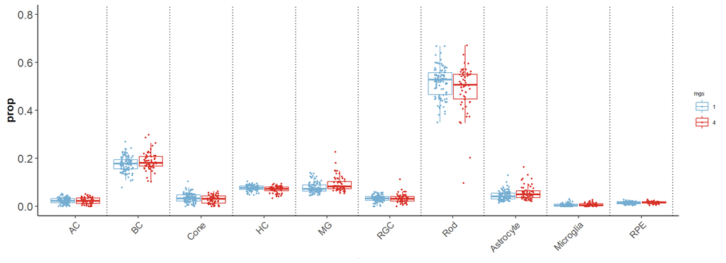

```r
# Visualize deconvolution results (Non-AMD vs AMD)

# Cell types to visualize and color scheme
  cell.order = c("AC", "BC", "Cone", "HC", "MG", "RGC", "Rod", "Astrocyte", "Microglia", "RPE")
  cls = rev(brewer.pal(n = 8, name = "RdYlBu"))[c(2,6:8)][c(1,4)]

# Select the non-AMD (mgs_level = 1) and AMD samples (mgs_level = 4)
  samples = amd_cohort_clinical_info$sample_id[which(amd_cohort_clinical_info$mgs_level == 1 | amd_cohort_clinical_info$mgs_level == 4)]
  amd_cohort_clinical_info = amd_cohort_clinical_info[samples,]
  Est.prop = Est.prop.weighted$cell.type.proportions[,samples]

# Prepare proportion table
  data.fl = data.frame(AC = (round(Est.prop, 4))["AC",amd_cohort_clinical_info$sample_id],
                       BC = (round(Est.prop, 4))["BC",amd_cohort_clinical_info$sample_id],
                       Cone = (round(Est.prop, 4))["Cone",amd_cohort_clinical_info$sample_id],
                       HC = (round(Est.prop, 4))["HC",amd_cohort_clinical_info$sample_id],
                       MG = (round(Est.prop, 4))["MG",amd_cohort_clinical_info$sample_id],
                       RGC = (round(Est.prop, 4))["RGC",amd_cohort_clinical_info$sample_id],
                       Rod = (round(Est.prop, 4))["Rod",amd_cohort_clinical_info$sample_id],
                       Astrocyte = (round(Est.prop, 4))["Astrocyte",amd_cohort_clinical_info$sample_id],
                       Microglia = (round(Est.prop, 4))["Microglia",amd_cohort_clinical_info$sample_id],
                       RPE = (round(Est.prop, 4))["RPE",amd_cohort_clinical_info$sample_id],
                       mgs = as.factor(amd_cohort_clinical_info$mgs_level))

# Prepare data for box plot
  prop = NULL
  cell = NULL
  for (i in 1:10) {
    prop = c(prop, data.fl[,i])
    cell = c(cell, rep(colnames(data.fl)[i], 166))
  }
  data = data.frame(prop = prop,
                    mgs = rep(data.fl[,11], 10),
                    cell = factor(cell, levels =
                           c("AC", "BC", "Cone", "HC", "MG",
                             "RGC", "Rod", "Astrocyte", "Microglia", "RPE")))

# Boxplot visualize the estimated cell-type proportion between healthy and AMD conditions
  amd.cohort.proportion =
    data %>%
      ggplot(aes(x = cell, y = prop, color = mgs))+theme_classic() +
      geom_boxplot(aes(color=mgs), alpha = 0.7, position=position_dodge(0.8), outlier.shape = NA)+
      geom_point(position = position_jitterdodge(), size = 0.5)+
      geom_vline(xintercept = seq(1.5, 11.5, 1), col="black", lty=3) +
      scale_color_manual(values=cls) +
      scale_fill_manual(values=cls) +
      theme(title=element_text(size=6), axis.text.x=element_text(size=10, angle=45, hjust=1),
            axis.title.x=element_text(size=0), axis.text.y=element_text(size=12),
            axis.title.y=element_text(size=12, face="bold"), legend.position = "right",
            legend.text=element_text(size=6), legend.title=element_text(size=6)) + ylim(0, 0.8)

  print(amd.cohort.proportion)
```

```r
# Compare DeMixSC estimates with experimental measures

# The experimentally measure mean proportions of healthy aged peripheral retina tissues (Liang et al., 2019)
# AC: 7.74%; BC: 15.6%; Cone: 4.61%; HC: 3.61%; MG: 14.08%; RGC: 1.07%; Rod: 53.29%.
  expr_prop = c(7.74,15.6,4.61,3.61,14.08,1.07,53.29)/100

# Obtain the estimated proportion from DeMixSC
  demixsc_prop = NULL
  for (i in 1:10) {
    demixsc_prop = c(demixsc_prop, round(mean(data.fl[which(data.fl$mgs == 1),i]), 4))
  }
  names(demixsc_prop) = colnames(data.fl)[1:10]
  demixsc_prop[1:7] = demixsc_prop[1:7]/sum(demixsc_prop[1:7])

# Calculate RMSE and Spearman correlation
  print(paste0("The RMSE value is: ",
               round(rmse(demixsc_prop[1:7], expr_prop),2)))
```

```
## [1] "The RMSE value is: 0.04"
```

```r
  print(paste0("The Spearman cor. is: ",
               round(cor(demixsc_prop[1:7], expr_prop, method = "spearman"),2)))
```

```
## [1] "The Spearman cor. is: 0.75"
```

## Example-2: Deconvolve the Lee et al., HGSC cohort with DeMixSC (`option = "hgsc"`)

In this section, we demonstrate how to deconvolve the `Lee et al., HGSC cohort` using the prebuilt `HGSC benchmark dataset` and `consensus references` with DeMixSC.

The performance of the deconvolution is validated by comparing the estimated macrophage proportions to the experimental staining results.

```r
# Load the raw count data for the HGSC cohort
  lee_cohort_raw_counts = get("hgsc_lee_cohort_raw_counts", envir = asNamespace("DeMixSC"))
  lee_cohort_clinical_info = get("hgsc_lee_cohort_clinical_info", envir = asNamespace("DeMixSC"))
  lee_cohort_mc_staining = get("hgsc_lee_cohort_mc_staining", envir = asNamespace("DeMixSC"))
```

- Components of the Lee et al., HGSC dataset:
  - `lee_cohort_raw_counts`: A raw count matrix of gene expression data for the Lee et al. HGSC cohort. This dataset contains 41 bulk RNA-seq samples from 30 patients.
  - `lee_cohort_clinical_info`: Includes sample IDs (`external_id`, `sequencing_id`, `clinical_sample_id`) and response to neoadjuvant chemotherapy (`response`).
  - `lee_cohort_mc_staining`: Includes sample ID (`external_id`), quantitative measure of macrophage staining results (`Macrophages`), and response to neoadjuvant chemotherapy (`response`).

```r
# Run DeMixSC deconvolution for the HGSC cohort
  Est.prop.weighted = DeMixSC(option = "hgsc",
                              benchmark.mode = FALSE,
                              mat.target = lee_cohort_raw_counts,
                              min.expression = 5,
                              scale.factor = 1e6,
                              adjp.cutoff = 0.05,
                              log2fc.cutoff = 0.75,
                              top.ranked.genes = 7000,
                              adj.factor = 2000,
                              c = 2,
                              iter.max = 2000,
                              eps = 0.001,
                              nthread = (detectCores()[1] - 1),
                              print.sample = 1,
                              output.file = "./DeMixSC.save.iter.txt")
```

```
## Data input check:
##  Benchmark mode is disabled, and `mat.target` is provided.
##  DeMixSC will proceed in real data mode.
## Running DeMixSC in HGSC mode with the provided HGSC benchmark data and reference...
## DeMixSC preprocessing has started.
## Target bulk provided. Running the DeMixSC real data mode.
## Note: DeMixSC typically converges in <600 iterations under the default convergence threshold (esp=0.001).
## For demonstration, proportions from each iteration of the first sample are recorded by default.
## Iterative data will be stored in the file: "./DeMixSC.save.iter.txt".
## Note: DeMixSC defaults to using (max.cores-1). Be cautious to avoid system overload. Consider adjusting `nthread` if needed.
## Starting parallel computation...
## Parallel computation completed.
## Deconvolution tasks completed!
```

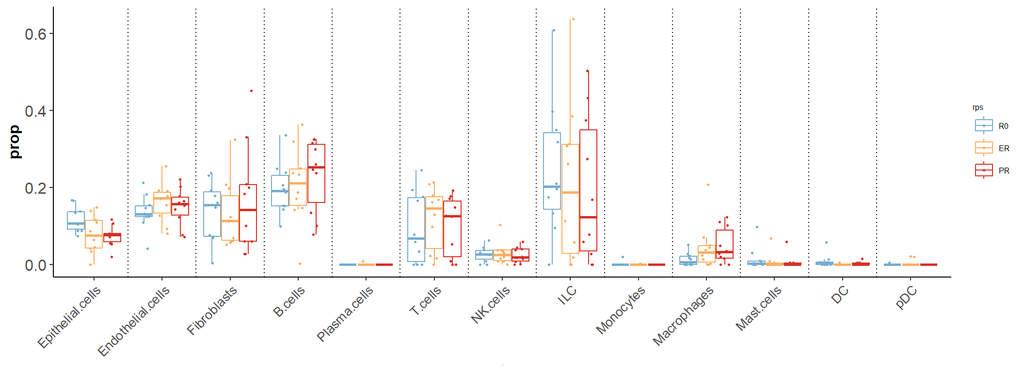

```r
# Visualize the deconvolution results (E0 vs ER vs PR)

# Plot the estimated cell-type proportions
  Est.prop = Est.prop.weighted$cell.type.proportions
  data.fl = data.frame(B.cells = (round(Est.prop, 4))["B.cells",],
                       Plasma.cells = (round(Est.prop, 4))["Plasma.cells",],
                       T.cells = (round(Est.prop, 4))["T.cells",],
                       NK.cells = (round(Est.prop, 4))["NK.cells",],
                       ILC = (round(Est.prop, 4))["ILC",],
                       Monocytes = (round(Est.prop, 4))["Monocytes",],
                       DC = (round(Est.prop, 4))["DC",],
                       pDC = (round(Est.prop, 4))["pDC",],
                       Macrophages = (round(Est.prop, 4))["Macrophages",],
                       Mast.cells = (round(Est.prop, 4))["Mast.cells",],
                       Endothelial.cells = (round(Est.prop, 4))["Endothelial.cells",],
                       Fibroblasts = (round(Est.prop, 4))["Fibroblasts",],
                       Epithelial.cells = (round(Est.prop, 4))["Epithelial.cells",],
                       rps = factor(lee_cohort_clinical_info$response, levels = c("R0", "ER", "PR")),
                       patient = lee_cohort_clinical_info$clinical_sample_id,
                       seqid = lee_cohort_clinical_info$external_id)

# Clean up the final proportion table by merging replicates
  data.fl$seqid <- gsub("-?R$", "", data.fl$seqid)
  result <- data.fl %>%
    group_by(seqid) %>%
    summarise(across(where(is.numeric), mean, na.rm = TRUE),
              across(where(is.character), ~first(.)))
  lee_cohort_clinical_info$seqid = gsub("-?R$", "", lee_cohort_clinical_info$external_id)
  result = data.frame(result)
  row.names(result) = result$seqid

# Prepare data for box plot
  rps = NULL
  patient = NULL
  for (i in row.names(result)) {
    id = which(lee_cohort_clinical_info$seqid == i)[1]
    rps = c(rps, lee_cohort_clinical_info$response[id])
    patient = c(patient, lee_cohort_clinical_info$clinical_sample_id[id])
  }
  result$rps = factor(rps, levels = c("R0", "ER", "PR"))
  result$patient=patient
  cls = rev(brewer.pal(n = 8, name = "RdYlBu"))[c(2,6:8)][c(1,2,4)]
  prop = NULL
  cell = NULL
  for (i in 2:14) {
    prop = c(prop, result[,i])
    cell = c(cell, rep(colnames(result)[i], length(result$seqid) ))
  }
  data = data.frame(prop = prop,
                    rps  = rep(result$rps, 13),
                    cell = factor(cell,
                                  levels = c("Epithelial.cells",
                                             "Endothelial.cells", "Fibroblasts",
                                             "B.cells", "Plasma.cells", "T.cells",
                                             "NK.cells", "ILC",
                                             "Monocytes", "Macrophages",
                                             "Mast.cells","DC", "pDC" )) )

# Boxplot visualize the estimated cell-type proportion across different response groups
  hgsc.cohort.proportion =
    data %>%
      ggplot(aes(x = cell, y = prop, color = rps))+theme_classic() +
      geom_boxplot(aes(color=rps), alpha = 0.7, position=position_dodge(0.8),outlier.shape = NA)+
      geom_point(position = position_jitterdodge(), size = 0.5)+
      geom_vline(xintercept = seq(1.5, 12.5, 1), col="black", lty=3) +
      scale_color_manual(values=cls) +
      scale_fill_manual(values=cls) +
      theme(title=element_text(size=6), axis.text.x=element_text(size=10, angle=45, hjust=1),
            axis.title.x=element_text(size=0), axis.text.y=element_text(size=12),
            axis.title.y=element_text(size=12, face="bold"), legend.position = "right",
            legend.text=element_text(size=6), legend.title=element_text(size=6))

  print(hgsc.cohort.proportion)
```

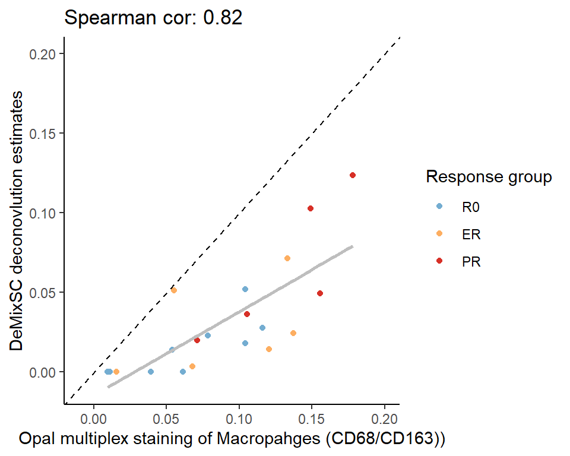

```r
# Compare DeMixSC estimates with experimental measures

# Subset the 21 samples with matched staining data for macrophages
  result_staining = result[lee_cohort_mc_staining$external_id,]

# Prepare input data for scatter plot visualization
  df.scatter = data.frame(
    staining = lee_cohort_mc_staining$Macrophages,
    demixsc = result_staining$Macrophages,
    group = result_staining$rps
  )

# Scatter plot comparing staining data with DeMixSC estimates
  hgsc.macrophage.comparison =
  ggplot(df.scatter, aes(x = staining, y = demixsc, color = group)) +
    geom_point(size = 1.5) +
    # Add spearman correlation
    labs(title = paste0("Spearman cor: ", round(cor(df.scatter$staining,
                                                    df.scatter$demixsc,
                                                    method = "spearman"), 2)
                        ),
         x = "Opal multiplex staining of Macropahges (CD68/CD163))",
         y = "DeMixSC deconovlution estimates",
         color = "Response group") +
    xlim(-0.01, 0.2) +
    ylim(-0.01, 0.2) +
    geom_smooth(method = "lm", se = FALSE, linetype = "solid", color = "grey") +
    geom_abline(intercept = 0, slope = 1, linetype = "dashed", color = "black") +
    scale_color_manual(values = c("R0" = "#74ADD1", "ER" = "#FDAE61", "PR" = "#D73027")) +
    theme_classic()

  print(hgsc.macrophage.comparison)
```

## Example-3: Deconvolve the retina and HGSC benchmark data with DeMixSC (`option = "user.defined"`)

In this section, we demonstrate how to apply DeMixSC using user-provided `benchmark data`.

This example tests the performance of DeMixSC with newly generated benchmark datasets.

We use the `retina benchmark dataset batch-1` as an example and evaluate the deconvolution performance using the root mean squared error (RMSE) compared to ground truth proportions.

```r
# Load benchmark and reference data (retina benchmark dataset batch-1)
  benchmark_bulk       = get("retina_benchmark_bulk_batch1", envir = asNamespace("DeMixSC"))
  benchmark_pseudobulk = get("retina_benchmark_pseudobulk_batch1", envir = asNamespace("DeMixSC"))
  benchmark_ref        = get("retina_benchmark_reference_batch1", envir = asNamespace("DeMixSC"))
```

- Note: users can easily test the performance of DeMixSC on `retina benchmark dataset batch-2` by loading the following data:

```r
# Load benchmark and reference data (retina benchmark dataset batch-2)
  benchmark_bulk       = get("retina_benchmark_bulk_batch2", envir = asNamespace("DeMixSC"))
  benchmark_pseudobulk = get("retina_benchmark_pseudobulk_batch2", envir = asNamespace("DeMixSC"))
  benchmark_ref        = get("retina_benchmark_reference_batch2", envir = asNamespace("DeMixSC"))
```

```r
# Run DeMixSC deconvolution on the retina benchmark data
  results = DeMixSC(option = "user.defined",
                    benchmark.mode = TRUE,
                    reference = benchmark_ref$reference,
                    mat.a = benchmark_bulk,
                    mat.b = benchmark_pseudobulk,
                    min.expression = 5,
                    scale.factor = 1e5,
                    adjp.cutoff = 0.05,
                    log2fc.cutoff = 1,
                    top.ranked.genes = 5000,
                    adj.factor = 1000,
                    c = 2,
                    iter.max = 2000,
                    eps = 0.001,
                    nthread = (detectCores()[1] - 1),
                    print.sample = 1,
                    output.file = "./DeMixSC.save.iter.txt")
```

```
## Data input check:
##  Benchmark mode is enabled, and no `mat.target` is provided.
##  DeMixSC will proceed in benchmark mode.
## Running DeMixSC in user-defined mode...
## DeMixSC preprocessing has started.
## No target bulk provided. Running the DeMixSC benchmark mode.
## Start to deconvolve bulk benchmark data...
## Note: DeMixSC defaults to using (max.cores-1). Be cautious to avoid system overload. Consider adjusting `nthread` if needed.
## Starting parallel computation...
## Parallel computation completed.
## Deconvolution tasks completed!
## Start to deconvolve pseudo-bulk benchmark data...
## Note: DeMixSC defaults to using (max.cores-1). Be cautious to avoid system overload. Consider adjusting `nthread` if needed.
## Starting parallel computation...
## Parallel computation completed.
## Deconvolution tasks completed!
```

- DeMixSC deconvolution outputs when `mat.target` is `NULL`:
  - `prop.est_bulk`: A matrix of estimated cell-type proportions for the bulk benchmark data (`mat.a`), where rows are cell types and columns are samples.
  - `prop.est_pseudobulk`: A matrix of estimated cell-type proportions for the pseudo-bulk benchmark data (`mat.b`), where rows are cell types and columns are samples.

```r
# Save the estimated cell-type proportions of the bulk and pseudo-bulk data
  prop.est_bulk = results$bulk.prop
  prop.est_pseudobulk = results$pseudobulk.prop
```

We use the root mean squared error (RMSE) to evaluate DeMixSC’s performance in deconvolving benchmark data.

```r
# Load the ground truth
  retina_truth_proportion = get("retina_benchmark_ground_truth", envir = asNamespace("DeMixSC"))

  cell.order = c("AC","BC","Cone","HC","MG","RGC","Rod")
```

```r
# The RMSE values in the bulk data (one for each sample)
  print("The RMSE values for the real-bulk samples")
```

```
## [1] "The RMSE values for the real-bulk samples"
```

```r
  for (i in colnames(prop.est_bulk)) {
    print(rmse(retina_truth_proportion[cell.order,i], prop.est_bulk[cell.order,i]))
  }
```

```
## [1] 0.01251733
## [1] 0.04347993
## [1] 0.03052875
## [1] 0.02145519
```

```r
# The RMSE values in the pseudo-bulk data (one for each sample)
  print("The RMSE values for the pseudo-bulk samples")
```

```
## [1] "The RMSE values for the pseudo-bulk samples"
```

```r
  for (i in colnames(prop.est_pseudobulk)) {
    print(rmse(retina_truth_proportion[cell.order,i], prop.est_pseudobulk[cell.order,i]))
  }
```

```
## [1] 0.007657942
## [1] 0.01040097
## [1] 0.01506553
## [1] 0.009986769
```

Additionally, we illustrate how to extend the analysis to other datasets, such as the `HGSC benchmark dataset`.

```r
# Laod the HGSC benchmark dataset
  benchmark_bulk        = get("hgsc_benchmark_bulk", envir = asNamespace("DeMixSC"))
  benchmark_pseudobulk  = get("hgsc_benchmark_pseudobulk", envir = asNamespace("DeMixSC"))
  benchmark_ref         = get("hgsc_benchmark_reference", envir = asNamespace("DeMixSC"))
  hgsc_truth_proportion = get("hgsc_benchmark_ground_truth", envir = asNamespace("DeMixSC"))

# Run DeMixSC deconvolution on the HGSC benchmark data
  results = DeMixSC(option = "user.defined",
                    benchmark.mode = TRUE,
                    reference = benchmark_ref$reference,
                    mat.a = benchmark_bulk,
                    mat.b = benchmark_pseudobulk,
                    min.expression = 5,
                    scale.factor = 1e5,
                    adjp.cutoff = 0.05,
                    log2fc.cutoff = 1,
                    top.ranked.genes = 2000,
                    adj.factor = 1000,
                    c = 2,
                    iter.max = 2000,
                    eps = 0.001,
                    nthread = (detectCores()[1] - 1),
                    print.sample = 5,
                    output.file = "./DeMixSC.save.iter.txt")

# Save the estimated cell-type proportions of the bulk and pseudo-bulk data
  prop.est_bulk = results$bulk.prop
  prop.est_pseudobulk = results$pseudobulk.prop

# load the ground truth.
  cell.order = c("Epithelial cells","Endothelial cells","Fibroblasts",
                 "B cells","Plasma cells","T cells","ILC","NK cells",
                 "Monocytes","DC","pDC","Macrophages","Mast cells")

# The RMSE values in the bulk data (one for each sample)
  print("The RMSE values for the real-bulk samples")
  for (i in colnames(prop.est_bulk)) {
    print(rmse(hgsc_truth_proportion[cell.order,i], prop.est_bulk[cell.order,i]))
  }

# The RMSE values in the pseudo-bulk data (one for each sample)
  print("The RMSE values for the pseudo-bulk samples")
  for (i in colnames(prop.est_pseudobulk)) {
    print(rmse(hgsc_truth_proportion[cell.order,i], prop.est_pseudobulk[cell.order,i]))
  }
```

## Example-4: Deconvolve a target bulk cohort with a user-provded benchmark data with DeMixSC (`option = "user.defined"`)

In this section, we use the AMD retina cohort as an example to demonstrate how to deconvolve a target bulk RNA-seq cohort with user-provided benchmark data using DeMixSC.

Users need to prepare their own `reference` and `benchmark dataset` to apply DeMixSC for estimating cell-type proportions in their target bulk RNA-seq dataset.

**Generating a custom reference matrix with DeMixSC (Optional)**: DeMixSC requires a reference matrix with genes as rows and cell types as columns. Users are free to generate their own cell-type-specific reference matrix using any approach they prefer. Please refer to our provided examples for the correct format. For convenience, we provide the function `DeMixSC.ref`, which allows users to easily construct a reference matrix from the single-cell Seurat object. Below is an example of how to use `DeMixSC.ref`:

```r
# Build cell-type-specific reference from Seurat object
  ref = DeMixSC.ref(Seurat.obj = Seurat.obj, annotation = annotation)
  reference = ref$reference
```

- Inputs:
  - `Seurat.obj`: The pre-annotated single-cell Seurat object.
  - `annotation`: A scalar or a character string to designate the column for cell-type information in the Seurat object.
- Outputs:
  - `reference`: A matrix of the reference expression, with genes on the rows and cell types on the columns.
  - `theta`: A matrix of the expression abundance relative to total UMI count per cell type, with genes on the rows and cell types on the columns.
  - `cell.size`: A vector of the mean cell size for each cell type.
- Note: Users can apply `DeMixSC.ref` to multiple Seurat objects to calculate the mean `theta` and `cell.size` to build the consensus reference.

```r
# Load benchmark, reference data and target bulk cohort
  amd_cohort_raw_counts = get("retina_amd_cohort_raw_counts", envir = asNamespace("DeMixSC"))
  reference             = get("retina_consensus_reference", envir = asNamespace("DeMixSC"))
  benchmark_bulk        = get("retina_benchmark_bulk_batch2", envir = asNamespace("DeMixSC"))
  benchmark_pseudobulk  = get("retina_benchmark_pseudobulk_batch2", envir = asNamespace("DeMixSC"))
```

```r
# Run DeMixSC deconvolution on the AMD retina cohort with retina benchmark data
  Est.prop.weighted = DeMixSC(option = "user.defined",
                              benchmark.mode = FALSE,
                              reference = reference,
                              mat.a = benchmark_bulk,
                              mat.b = benchmark_pseudobulk,
                              mat.target = amd_cohort_raw_counts,
                              min.expression = 3,
                              scale.factor = 1e5,
                              adjp.cutoff = 0.05,
                              log2fc.cutoff = 0.75,
                              top.ranked.genes = 1500,
                              adj.factor = 1000,
                              c = 2,
                              iter.max = 2000,
                              eps = 0.001,
                              nthread = (parallel::detectCores()[1] - 1),
                              print.sample = 1,
                              output.file = "./DeMixSC.save.iter.txt")

# User can use previous data visualization code of AMD cohort to check the deconvolution results
```

## License

GNU Affero General Public License v3.0

## Connect With Us

Please contact Shuai Guo (SGuo3@mdanderson.org), Xiaoqian Liu (xiaoqian.liu@ucr.edu), Ruonan Li (RLi10@mdanderson.org), and Wenyi Wang (WWang7@mdanderson.org) if you encounter any issues when processing this tutorial.

## Reference

*Guo, S., Liu, X., Cheng, X., Jiang, Y., Ji, S., Liang, Q., … & Wang, W. (2023). The DeMixSC deconvolution framework uses single-cell sequencing plus a small benchmark dataset for improved analysis of cell-type ratios in complex tissue samples. bioRxiv, 2023-10.*  
https://doi.org/10.1101/2023.10.10.561733  
*Liang, Q., Dharmat, R., Owen, L., Shakoor, A., Li, Y., Kim, S., … & Chen, R. (2019). Single-nuclei RNA-seq on human retinal tissue provides improved transcriptome profiling. Nature communications, 10(1), 5743.*  
https://www.nature.com/articles/s41467-019-12917-9  
*Ratnapriya, R., Sosina, O. A., Starostik, M. R., Kwicklis, M., Kapphahn, R. J., Fritsche, L. G., … & Swaroop, A. (2019). Retinal transcriptome and eQTL analyses identify genes associated with age-related macular degeneration. Nature genetics, 51(4), 606-610.*  
https://www.nature.com/articles/s41588-019-0351-9  
*Hippen, A. A., Omran, D. K., Weber, L. M., Jung, E., Drapkin, R., Doherty, J. A., … & Greene, C. S. (2023). Performance of computational algorithms to deconvolve heterogeneous bulk ovarian tumor tissue depends on experimental factors. Genome biology, 24(1), 239.*  
https://genomebiology.biomedcentral.com/articles/10.1186/s13059-023-03077-7  
*Lee, S., Zhao, L., Rojas, C., Bateman, N. W., Yao, H., Lara, O. D., … & Sood, A. K. (2020). Molecular analysis of clinically defined subsets of high-grade serous ovarian cancer. Cell reports, 31(2).*  
https://www.cell.com/cell-reports/fulltext/S2211-1247(20)30392-2